# Part I - (Dataset Exploration on Loan Data from Prosper)

## by (Jedidah Kariuki)

- 1. Introduction
- 2. Preliminary Wrangling
- 3. Univariate Exploration
- 4. Bivariate Exploration
- 5. Multivariate Exploration
- 6. Conclusion
- 7. Reference

## Introduction

This dataset represents thousands of loans made through Prosper platform which is a peer-to-peer lending marketplace based in San Franciso, California. The dataset contains 113,937 loans with 81 variables on each loan, including loan amount, borrower or interest rate, current loan status, borrower income and many others.

## Preliminary Wrangling

```python
# import all packages and set plots to be embedded inline
import numpy as np
import pandas as pd
import matplotlib.pyplot as plt
import seaborn as sb

%matplotlib inline
```

```python
import warnings
warnings.filterwarnings('ignore')
```

```python
#Loading the dataset

loan_df = pd.read_csv("prosperLoanData.csv")
```

```python
#Getting information and overview of the dataset
print(loan_df.shape)
loan_df.info()
```

```
(113937, 81)
<class 'pandas.core.frame.DataFrame'>
RangeIndex: 113937 entries, 0 to 113936
Data columns (total 81 columns):
ListingKey                             113937 non-null object
ListingNumber                          113937 non-null int64
ListingCreationDate                    113937 non-null object
CreditGrade                            28953 non-null object
Term                                   113937 non-null int64
LoanStatus                             113937 non-null object
ClosedDate                             55089 non-null object
BorrowerAPR                            113912 non-null float64
BorrowerRate                           113937 non-null float64
LenderYield                            113937 non-null float64
EstimatedEffectiveYield                84853 non-null float64
EstimatedLoss                          84853 non-null float64
EstimatedReturn                        84853 non-null float64
ProsperRating (numeric)                84853 non-null float64
ProsperRating (Alpha)                  84853 non-null object
ProsperScore                           84853 non-null float64
ListingCategory (numeric)              113937 non-null int64
BorrowerState                          108422 non-null object
Occupation                             110349 non-null object
EmploymentStatus                       111682 non-null object
EmploymentStatusDuration               106312 non-null float64
IsBorrowerHomeowner                    113937 non-null bool
CurrentlyInGroup                       113937 non-null bool
GroupKey                               13341 non-null object
DateCreditPulled                       113937 non-null object
CreditScoreRangeLower                  113346 non-null float64
CreditScoreRangeUpper                  113346 non-null float64
FirstRecordedCreditLine                113240 non-null object
CurrentCreditLines                     106333 non-null float64
OpenCreditLines                        106333 non-null float64
TotalCreditLinespast7years             113240 non-null float64
OpenRevolvingAccounts                  113937 non-null int64
OpenRevolvingMonthlyPayment            113937 non-null float64
InquiriesLast6Months                   113240 non-null float64
TotalInquiries                         112778 non-null float64
CurrentDelinquencies                   113240 non-null float64
```

[output cut: 32 more lines]

```
LP_CustomerPayments                    113937 non-null float64
LP_CustomerPrincipalPayments           113937 non-null float64
LP_InterestandFees                     113937 non-null float64
LP_ServiceFees                         113937 non-null float64
LP_CollectionFees                      113937 non-null float64
LP_GrossPrincipalLoss                  113937 non-null float64
LP_NetPrincipalLoss                    113937 non-null float64
LP_NonPrincipalRecoverypayments        113937 non-null float64
PercentFunded                          113937 non-null float64
Recommendations                        113937 non-null int64
InvestmentFromFriendsCount             113937 non-null int64
InvestmentFromFriendsAmount            113937 non-null float64
Investors                              113937 non-null int64
dtypes: bool(3), float64(50), int64(11), object(17)
memory usage: 68.1+ MB
```

```python
loan_df.head(10)
```

|  | ListingKey | ListingNumber | ListingCreationDate | CreditGrade | Term | LoanStatus | ClosedDate | BorrowerAPR | BorrowerRate | LenderYield | ... | LP_ServiceFees | LP_CollectionFees | LP_GrossPrincipalLoss | LP_NetPrincipalLoss | LP_NonPrincipalRecoverypayments | PercentFunded | Recommendations | InvestmentFromFriendsCount | InvestmentFromFriendsAmount | Investors |
| --- | --- | --- | --- | --- | --- | --- | --- | --- | --- | --- | --- | --- | --- | --- | --- | --- | --- | --- | --- | --- | --- |
| 0 | 1021339766868145413AB3B | 193129 | 2007-08-26 19:09:29.263000000 | C | 36 | Completed | 2009-08-14 00:00:00 | 0.16516 | 0.1580 | 0.1380 | ... | -133.18 | 0.0 | 0.0 | 0.0 | 0.0 | 1.0 | 0 | 0 | 0.0 | 258 |
| 1 | 10273602499503308B223C1 | 1209647 | 2014-02-27 08:28:07.900000000 | NaN | 36 | Current | NaN | 0.12016 | 0.0920 | 0.0820 | ... | 0.00 | 0.0 | 0.0 | 0.0 | 0.0 | 1.0 | 0 | 0 | 0.0 | 1 |
| 2 | 0EE9337825851032864889A | 81716 | 2007-01-05 15:00:47.090000000 | HR | 36 | Completed | 2009-12-17 00:00:00 | 0.28269 | 0.2750 | 0.2400 | ... | -24.20 | 0.0 | 0.0 | 0.0 | 0.0 | 1.0 | 0 | 0 | 0.0 | 41 |
| 3 | 0EF5356002482715299901A | 658116 | 2012-10-22 11:02:35.010000000 | NaN | 36 | Current | NaN | 0.12528 | 0.0974 | 0.0874 | ... | -108.01 | 0.0 | 0.0 | 0.0 | 0.0 | 1.0 | 0 | 0 | 0.0 | 158 |
| 4 | 0F023589499656230C5E3E2 | 909464 | 2013-09-14 18:38:39.097000000 | NaN | 36 | Current | NaN | 0.24614 | 0.2085 | 0.1985 | ... | -60.27 | 0.0 | 0.0 | 0.0 | 0.0 | 1.0 | 0 | 0 | 0.0 | 20 |
| 5 | 0F05359734824199381F61D | 1074836 | 2013-12-14 08:26:37.093000000 | NaN | 60 | Current | NaN | 0.15425 | 0.1314 | 0.1214 | ... | -25.33 | 0.0 | 0.0 | 0.0 | 0.0 | 1.0 | 0 | 0 | 0.0 | 1 |
| 6 | 0F0A3576754255009D63151 | 750899 | 2013-04-12 09:52:56.147000000 | NaN | 36 | Current | NaN | 0.31032 | 0.2712 | 0.2612 | ... | -22.95 | 0.0 | 0.0 | 0.0 | 0.0 | 1.0 | 0 | 0 | 0.0 | 1 |
| 7 | 0F1035772717087366F9EA7 | 768193 | 2013-05-05 06:49:27.493000000 | NaN | 36 | Current | NaN | 0.23939 | 0.2019 | 0.1919 | ... | -69.21 | 0.0 | 0.0 | 0.0 | 0.0 | 1.0 | 0 | 0 | 0.0 | 1 |
| 8 | 0F043596202561788EA13D5 | 1023355 | 2013-12-02 10:43:39.117000000 | NaN | 36 | Current | NaN | 0.07620 | 0.0629 | 0.0529 | ... | -16.77 | 0.0 | 0.0 | 0.0 | 0.0 | 1.0 | 0 | 0 | 0.0 | 1 |
| 9 | 0F043596202561788EA13D5 | 1023355 | 2013-12-02 10:43:39.117000000 | NaN | 36 | Current | NaN | 0.07620 | 0.0629 | 0.0529 | ... | -16.77 | 0.0 | 0.0 | 0.0 | 0.0 | 1.0 | 0 | 0 | 0.0 | 1 |

10 rows × 81 columns

```python
loan_df.tail(10)
```

|  | ListingKey | ListingNumber | ListingCreationDate | CreditGrade | Term | LoanStatus | ClosedDate | BorrowerAPR | BorrowerRate | LenderYield | ... | LP_ServiceFees | LP_CollectionFees | LP_GrossPrincipalLoss | LP_NetPrincipalLoss | LP_NonPrincipalRecoverypayments | PercentFunded | Recommendations | InvestmentFromFriendsCount | InvestmentFromFriendsAmount | Investors |
| --- | --- | --- | --- | --- | --- | --- | --- | --- | --- | --- | --- | --- | --- | --- | --- | --- | --- | --- | --- | --- | --- |
| 113927 | E3433419834735803891976 | 322787 | 2008-04-30 21:25:19.670000000 | AA | 36 | Completed | 2011-05-09 00:00:00 | 0.07469 | 0.0679 | 0.0579 | ... | -68.47 | 0.0 | 0.0 | 0.0 | 0.0 | 1.0 | 2 | 0 | 0.0 | 194 |
| 113928 | E34935176664905343E01EA | 510097 | 2011-06-06 19:02:44.443000000 | NaN | 36 | Completed | 2011-09-19 00:00:00 | 0.22362 | 0.1899 | 0.1799 | ... | -4.41 | 0.0 | 0.0 | 0.0 | 0.0 | 1.0 | 0 | 0 | 0.0 | 25 |
| 113929 | E3553583161337791FCB87F | 830413 | 2013-07-06 17:40:01.657000000 | NaN | 36 | Completed | 2014-02-07 00:00:00 | 0.30285 | 0.2639 | 0.2539 | ... | -6.54 | 0.0 | 0.0 | 0.0 | 0.0 | 1.0 | 0 | 0 | 0.0 | 26 |
| 113930 | E35D3584034795373BCD69A | 831523 | 2013-07-08 10:24:49.700000000 | NaN | 36 | Current | NaN | 0.20053 | 0.1639 | 0.1539 | ... | -16.51 | 0.0 | 0.0 | 0.0 | 0.0 | 1.0 | 0 | 0 | 0.0 | 52 |
| 113931 | E36F36005339663245C20F8 | 1141292 | 2014-01-16 20:13:08.040000000 | NaN | 60 | Current | NaN | 0.15016 | 0.1274 | 0.1174 | ... | -21.23 | 0.0 | 0.0 | 0.0 | 0.0 | 1.0 | 0 | 0 | 0.0 | 1 |
| 113932 | E6D9357655724827169606C | 753087 | 2013-04-14 05:55:02.663000000 | NaN | 36 | Current | NaN | 0.22354 | 0.1864 | 0.1764 | ... | -75.58 | 0.0 | 0.0 | 0.0 | 0.0 | 1.0 | 0 | 0 | 0.0 | 1 |
| 113933 | E6DB353036033497292EE43 | 537216 | 2011-11-03 20:42:55.333000000 | NaN | 36 | FinalPaymentInProgress | NaN | 0.13220 | 0.1110 | 0.1010 | ... | -30.05 | 0.0 | 0.0 | 0.0 | 0.0 | 1.0 | 0 | 0 | 0.0 | 22 |
| 113934 | E6E13596170052029692BB1 | 1069178 | 2013-12-13 05:49:12.703000000 | NaN | 60 | Current | NaN | 0.23984 | 0.2150 | 0.2050 | ... | -16.91 | 0.0 | 0.0 | 0.0 | 0.0 | 1.0 | 0 | 0 | 0.0 | 119 |
| 113935 | E6EB3531504622671970D9E | 539056 | 2011-11-14 13:18:26.597000000 | NaN | 60 | Completed | 2013-08-13 00:00:00 | 0.28408 | 0.2605 | 0.2505 | ... | -235.05 | 0.0 | 0.0 | 0.0 | 0.0 | 1.0 | 0 | 0 | 0.0 | 274 |
| 113936 | E6ED3600409833199F711B7 | 1140093 | 2014-01-15 09:27:37.657000000 | NaN | 36 | Current | NaN | 0.13189 | 0.1039 | 0.0939 | ... | -1.70 | 0.0 | 0.0 | 0.0 | 0.0 | 1.0 | 0 | 0 | 0.0 | 1 |

10 rows × 81 columns

```python
#Descriptive statistics on numeric variables
loan_df.describe()
```

|  | ListingNumber | Term | BorrowerAPR | BorrowerRate | LenderYield | EstimatedEffectiveYield | EstimatedLoss | EstimatedReturn | ProsperRating (numeric) | ProsperScore | ... | LP_ServiceFees | LP_CollectionFees | LP_GrossPrincipalLoss | LP_NetPrincipalLoss | LP_NonPrincipalRecoverypayments | PercentFunded | Recommendations | InvestmentFromFriendsCount | InvestmentFromFriendsAmount | Investors |
| --- | --- | --- | --- | --- | --- | --- | --- | --- | --- | --- | --- | --- | --- | --- | --- | --- | --- | --- | --- | --- | --- |
| count | 1.139370e+05 | 113937.000000 | 113912.000000 | 113937.000000 | 113937.000000 | 84853.000000 | 84853.000000 | 84853.000000 | 84853.000000 | 84853.000000 | ... | 113937.000000 | 113937.000000 | 113937.000000 | 113937.000000 | 113937.000000 | 113937.000000 | 113937.000000 | 113937.000000 | 113937.000000 | 113937.000000 |
| mean | 6.278857e+05 | 40.830248 | 0.218828 | 0.192764 | 0.182701 | 0.168661 | 0.080306 | 0.096068 | 4.072243 | 5.950067 | ... | -54.725641 | -14.242698 | 700.446342 | 681.420499 | 25.142686 | 0.998584 | 0.048027 | 0.023460 | 16.550751 | 80.475228 |
| std | 3.280762e+05 | 10.436212 | 0.080364 | 0.074818 | 0.074516 | 0.068467 | 0.046764 | 0.030403 | 1.673227 | 2.376501 | ... | 60.675425 | 109.232758 | 2388.513831 | 2357.167068 | 275.657937 | 0.017919 | 0.332353 | 0.232412 | 294.545422 | 103.239020 |
| min | 4.000000e+00 | 12.000000 | 0.006530 | 0.000000 | -0.010000 | -0.182700 | 0.004900 | -0.182700 | 1.000000 | 1.000000 | ... | -664.870000 | -9274.750000 | -94.200000 | -954.550000 | 0.000000 | 0.700000 | 0.000000 | 0.000000 | 0.000000 | 1.000000 |
| 25% | 4.009190e+05 | 36.000000 | 0.156290 | 0.134000 | 0.124200 | 0.115670 | 0.042400 | 0.074080 | 3.000000 | 4.000000 | ... | -73.180000 | 0.000000 | 0.000000 | 0.000000 | 0.000000 | 1.000000 | 0.000000 | 0.000000 | 0.000000 | 2.000000 |
| 50% | 6.005540e+05 | 36.000000 | 0.209760 | 0.184000 | 0.173000 | 0.161500 | 0.072400 | 0.091700 | 4.000000 | 6.000000 | ... | -34.440000 | 0.000000 | 0.000000 | 0.000000 | 0.000000 | 1.000000 | 0.000000 | 0.000000 | 0.000000 | 44.000000 |
| 75% | 8.926340e+05 | 36.000000 | 0.283810 | 0.250000 | 0.240000 | 0.224300 | 0.112000 | 0.116600 | 5.000000 | 8.000000 | ... | -13.920000 | 0.000000 | 0.000000 | 0.000000 | 0.000000 | 1.000000 | 0.000000 | 0.000000 | 0.000000 | 115.000000 |
| max | 1.255725e+06 | 60.000000 | 0.512290 | 0.497500 | 0.492500 | 0.319900 | 0.366000 | 0.283700 | 7.000000 | 11.000000 | ... | 32.060000 | 0.000000 | 25000.000000 | 25000.000000 | 21117.900000 | 1.012500 | 39.000000 | 33.000000 | 25000.000000 | 1189.000000 |

8 rows × 61 columns

```python
print(loan_df.LoanStatus.value_counts())
print(loan_df.CreditGrade.value_counts())
print(loan_df['ProsperRating (Alpha)'].value_counts())
```

```
Current                   56576
Completed                 38074
Chargedoff                11992
Defaulted                  5018
Past Due (1-15 days)        806
Past Due (31-60 days)       363
Past Due (61-90 days)       313
Past Due (91-120 days)      304
Past Due (16-30 days)       265
FinalPaymentInProgress      205
Past Due (>120 days)         16
Cancelled                     5
Name: LoanStatus, dtype: int64
C     5649
D     5153
B     4389
AA    3509
HR    3508
A     3315
E     3289
NC     141
Name: CreditGrade, dtype: int64
C     18345
B     15581
A     14551
D     14274
E      9795
HR     6935
AA     5372
Name: ProsperRating (Alpha), dtype: int64
```

### What is the structure of your dataset?

There are 113,937 loans in the dataset with 81 features. Most features are numeric (61 features to be precise). The variables Loanstatus, CreditGrade and ProsperRating are categorical variables with the following levels:

- LoanStatus: Current, Completed, Chargedoff, Defaulted, Past Due(specifying by what period), Cancelled and FinalPaymentInProgress
- CreditGrade: A, AA, B, C, D, E, HR, NC
- ProsperRating: A, AA, B,C, D, E, HR

### What is/are the main feature(s) of interest in your dataset?

I'm interested in figuring out which features are best in:

- Determining the properties that lead to a higher amount of loan given
- Looking at the trend of the borrowing vs payment on this lending platform.
- The effect of the prosper rating and term on the loan amount

### What features in the dataset do you think will help support your investigation into your feature(s) of interest?

I expect that the CreditGrade and LoanStatus will affect the loan amount. The better the CreditGrade, the higher the amount of the loan amount. The loan status having an effect on the credit grade. The features that will help support in the investigation are CreditGrade, LoanStatus, LoanNumber and LoanOriginalAmount and a few other features related to the loan applicable. This will be depicted in the created subset of columns created below.

## Univariate Exploration

I'll start by creating a new dataframe containing the features that I'll need for the exploration.

```python
loan_df.columns
```

```
Index(['ListingKey', 'ListingNumber', 'ListingCreationDate', 'CreditGrade',
       'Term', 'LoanStatus', 'ClosedDate', 'BorrowerAPR', 'BorrowerRate',
       'LenderYield', 'EstimatedEffectiveYield', 'EstimatedLoss',
       'EstimatedReturn', 'ProsperRating (numeric)', 'ProsperRating (Alpha)',
       'ProsperScore', 'ListingCategory (numeric)', 'BorrowerState',
       'Occupation', 'EmploymentStatus', 'EmploymentStatusDuration',
       'IsBorrowerHomeowner', 'CurrentlyInGroup', 'GroupKey',
       'DateCreditPulled', 'CreditScoreRangeLower', 'CreditScoreRangeUpper',
       'FirstRecordedCreditLine', 'CurrentCreditLines', 'OpenCreditLines',
       'TotalCreditLinespast7years', 'OpenRevolvingAccounts',
       'OpenRevolvingMonthlyPayment', 'InquiriesLast6Months', 'TotalInquiries',
       'CurrentDelinquencies', 'AmountDelinquent', 'DelinquenciesLast7Years',
       'PublicRecordsLast10Years', 'PublicRecordsLast12Months',
       'RevolvingCreditBalance', 'BankcardUtilization',
       'AvailableBankcardCredit', 'TotalTrades',
       'TradesNeverDelinquent (percentage)', 'TradesOpenedLast6Months',
       'DebtToIncomeRatio', 'IncomeRange', 'IncomeVerifiable',
       'StatedMonthlyIncome', 'LoanKey', 'TotalProsperLoans',
       'TotalProsperPaymentsBilled', 'OnTimeProsperPayments',
       'ProsperPaymentsLessThanOneMonthLate',
       'ProsperPaymentsOneMonthPlusLate', 'ProsperPrincipalBorrowed',
       'ProsperPrincipalOutstanding', 'ScorexChangeAtTimeOfListing',
       'LoanCurrentDaysDelinquent', 'LoanFirstDefaultedCycleNumber',
       'LoanMonthsSinceOrigination', 'LoanNumber', 'LoanOriginalAmount',
       'LoanOriginationDate', 'LoanOriginationQuarter', 'MemberKey',
       'MonthlyLoanPayment', 'LP_CustomerPayments',
       'LP_CustomerPrincipalPayments', 'LP_InterestandFees', 'LP_ServiceFees',
       'LP_CollectionFees', 'LP_GrossPrincipalLoss', 'LP_NetPrincipalLoss',
       'LP_NonPrincipalRecoverypayments', 'PercentFunded', 'Recommendations',
       'InvestmentFromFriendsCount', 'InvestmentFromFriendsAmount',
       'Investors'],
      dtype='object')
```

```python
cols = ['ListingNumber','ListingCreationDate', 'CreditGrade','Term', 'LoanStatus', 'ProsperRating (Alpha)', 'BorrowerAPR',
        'BorrowerRate', 'BorrowerState', 'Occupation', 'EmploymentStatus','DebtToIncomeRatio',
        'StatedMonthlyIncome', 'LoanNumber', 'LoanOriginalAmount',
        'MonthlyLoanPayment', 'Investors']

new_loan_df = loan_df[cols]
new_loan_df.info()
```

```
<class 'pandas.core.frame.DataFrame'>
RangeIndex: 113937 entries, 0 to 113936
Data columns (total 17 columns):
ListingNumber            113937 non-null int64
ListingCreationDate      113937 non-null object
CreditGrade              28953 non-null object
Term                     113937 non-null int64
LoanStatus               113937 non-null object
ProsperRating (Alpha)    84853 non-null object
BorrowerAPR              113912 non-null float64
BorrowerRate             113937 non-null float64
BorrowerState            108422 non-null object
Occupation               110349 non-null object
EmploymentStatus         111682 non-null object
DebtToIncomeRatio        105383 non-null float64
StatedMonthlyIncome      113937 non-null float64
LoanNumber               113937 non-null int64
LoanOriginalAmount       113937 non-null int64
MonthlyLoanPayment       113937 non-null float64
Investors                113937 non-null int64
dtypes: float64(5), int64(5), object(7)
memory usage: 14.8+ MB
```

```python
new_loan_df[:10]
```

|  | ListingNumber | ListingCreationDate | CreditGrade | Term | LoanStatus | ProsperRating (Alpha) | BorrowerAPR | BorrowerRate | BorrowerState | Occupation | EmploymentStatus | DebtToIncomeRatio | StatedMonthlyIncome | LoanNumber | LoanOriginalAmount | MonthlyLoanPayment | Investors |
| --- | --- | --- | --- | --- | --- | --- | --- | --- | --- | --- | --- | --- | --- | --- | --- | --- | --- |
| 0 | 193129 | 2007-08-26 19:09:29.263000000 | C | 36 | Completed | NaN | 0.16516 | 0.1580 | CO | Other | Self-employed | 0.17 | 3083.333333 | 19141 | 9425 | 330.43 | 258 |
| 1 | 1209647 | 2014-02-27 08:28:07.900000000 | NaN | 36 | Current | A | 0.12016 | 0.0920 | CO | Professional | Employed | 0.18 | 6125.000000 | 134815 | 10000 | 318.93 | 1 |
| 2 | 81716 | 2007-01-05 15:00:47.090000000 | HR | 36 | Completed | NaN | 0.28269 | 0.2750 | GA | Other | Not available | 0.06 | 2083.333333 | 6466 | 3001 | 123.32 | 41 |
| 3 | 658116 | 2012-10-22 11:02:35.010000000 | NaN | 36 | Current | A | 0.12528 | 0.0974 | GA | Skilled Labor | Employed | 0.15 | 2875.000000 | 77296 | 10000 | 321.45 | 158 |
| 4 | 909464 | 2013-09-14 18:38:39.097000000 | NaN | 36 | Current | D | 0.24614 | 0.2085 | MN | Executive | Employed | 0.26 | 9583.333333 | 102670 | 15000 | 563.97 | 20 |
| 5 | 1074836 | 2013-12-14 08:26:37.093000000 | NaN | 60 | Current | B | 0.15425 | 0.1314 | NM | Professional | Employed | 0.36 | 8333.333333 | 123257 | 15000 | 342.37 | 1 |
| 6 | 750899 | 2013-04-12 09:52:56.147000000 | NaN | 36 | Current | E | 0.31032 | 0.2712 | KS | Sales - Retail | Employed | 0.27 | 2083.333333 | 88353 | 3000 | 122.67 | 1 |
| 7 | 768193 | 2013-05-05 06:49:27.493000000 | NaN | 36 | Current | C | 0.23939 | 0.2019 | CA | Laborer | Employed | 0.24 | 3355.750000 | 90051 | 10000 | 372.60 | 1 |
| 8 | 1023355 | 2013-12-02 10:43:39.117000000 | NaN | 36 | Current | AA | 0.07620 | 0.0629 | IL | Food Service | Employed | 0.25 | 3333.333333 | 121268 | 10000 | 305.54 | 1 |
| 9 | 1023355 | 2013-12-02 10:43:39.117000000 | NaN | 36 | Current | AA | 0.07620 | 0.0629 | IL | Food Service | Employed | 0.25 | 3333.333333 | 121268 | 10000 | 305.54 | 1 |

```python
#Let's drop the duplicates

new_loan_df.drop_duplicates()
```

|  | ListingNumber | ListingCreationDate | CreditGrade | Term | LoanStatus | ProsperRating (Alpha) | BorrowerAPR | BorrowerRate | BorrowerState | Occupation | EmploymentStatus | DebtToIncomeRatio | StatedMonthlyIncome | LoanNumber | LoanOriginalAmount | MonthlyLoanPayment | Investors |
| --- | --- | --- | --- | --- | --- | --- | --- | --- | --- | --- | --- | --- | --- | --- | --- | --- | --- |
| 0 | 193129 | 2007-08-26 19:09:29.263000000 | C | 36 | Completed | NaN | 0.16516 | 0.1580 | CO | Other | Self-employed | 0.17000 | 3083.333333 | 19141 | 9425 | 330.43 | 258 |
| 1 | 1209647 | 2014-02-27 08:28:07.900000000 | NaN | 36 | Current | A | 0.12016 | 0.0920 | CO | Professional | Employed | 0.18000 | 6125.000000 | 134815 | 10000 | 318.93 | 1 |
| 2 | 81716 | 2007-01-05 15:00:47.090000000 | HR | 36 | Completed | NaN | 0.28269 | 0.2750 | GA | Other | Not available | 0.06000 | 2083.333333 | 6466 | 3001 | 123.32 | 41 |
| 3 | 658116 | 2012-10-22 11:02:35.010000000 | NaN | 36 | Current | A | 0.12528 | 0.0974 | GA | Skilled Labor | Employed | 0.15000 | 2875.000000 | 77296 | 10000 | 321.45 | 158 |
| 4 | 909464 | 2013-09-14 18:38:39.097000000 | NaN | 36 | Current | D | 0.24614 | 0.2085 | MN | Executive | Employed | 0.26000 | 9583.333333 | 102670 | 15000 | 563.97 | 20 |
| 5 | 1074836 | 2013-12-14 08:26:37.093000000 | NaN | 60 | Current | B | 0.15425 | 0.1314 | NM | Professional | Employed | 0.36000 | 8333.333333 | 123257 | 15000 | 342.37 | 1 |
| 6 | 750899 | 2013-04-12 09:52:56.147000000 | NaN | 36 | Current | E | 0.31032 | 0.2712 | KS | Sales - Retail | Employed | 0.27000 | 2083.333333 | 88353 | 3000 | 122.67 | 1 |
| 7 | 768193 | 2013-05-05 06:49:27.493000000 | NaN | 36 | Current | C | 0.23939 | 0.2019 | CA | Laborer | Employed | 0.24000 | 3355.750000 | 90051 | 10000 | 372.60 | 1 |
| 8 | 1023355 | 2013-12-02 10:43:39.117000000 | NaN | 36 | Current | AA | 0.07620 | 0.0629 | IL | Food Service | Employed | 0.25000 | 3333.333333 | 121268 | 10000 | 305.54 | 1 |
| 10 | 587746 | 2012-05-10 07:04:01.577000000 | NaN | 60 | Current | C | 0.27462 | 0.2489 | MD | Fireman | Employed | 0.12000 | 7500.000000 | 65946 | 13500 | 395.37 | 19 |
| 11 | 213551 | 2007-10-09 20:28:33.640000000 | C | 36 | Completed | NaN | 0.15033 | 0.1325 | NaN | Waiter/Waitress | Full-time | 0.27000 | 1666.666667 | 20907 | 1000 | 33.81 | 53 |
| 12 | 1081604 | 2013-12-15 20:01:10.757000000 | NaN | 36 | Past Due (1-15 days) | B | 0.17969 | 0.1435 | AL | Sales - Retail | Employed | 0.18000 | 2416.666667 | 125045 | 4000 | 137.39 | 1 |
| 13 | 840820 | 2013-07-15 16:28:28.087000000 | NaN | 36 | Current | A | 0.13138 | 0.1034 | AZ | Construction | Employed | 0.09000 | 5833.333333 | 96202 | 8500 | 275.63 | 171 |
| 14 | 757359 | 2013-04-19 11:17:41.700000000 | NaN | 60 | Current | A | 0.11695 | 0.0949 | VA | Computer Programmer | Employed | 0.20000 | 10833.333333 | 90060 | 19330 | 415.37 | 371 |
| 15 | 577164 | 2012-04-10 09:14:46.297000000 | NaN | 36 | Defaulted | HR | 0.35797 | 0.3177 | FL | Other | Other | 0.49000 | 5500.000000 | 63982 | 4000 | 173.71 | 10 |
| 16 | 841846 | 2013-07-16 12:42:48.680000000 | NaN | 60 | Current | E | 0.30748 | 0.2809 | CA | Professional | Full-time | 0.15000 | 8291.666667 | 95921 | 4000 | 124.76 | 8 |
| 17 | 31540 | 2006-08-15 12:21:09.433000000 | AA | 36 | Chargedoff | NaN | 0.13202 | 0.1250 | NaN | Professional | Not available | 0.12000 | 5833.333333 | 2711 | 10000 | 334.54 | 85 |
| 18 | 716058 | 2013-02-20 03:48:37.470000000 | NaN | 36 | Current | A | 0.12528 | 0.0974 | PA | Sales - Commission | Employed | 0.24000 | 6250.000000 | 85974 | 15000 | 482.18 | 303 |
| 19 | 875565 | 2013-08-21 06:49:02.093000000 | NaN | 60 | Current | D | 0.24754 | 0.2225 | OR | Laborer | Employed | 0.41000 | 3075.000000 | 105323 | 6500 | 180.45 | 1 |
| 20 | 1011916 | 2013-11-22 11:35:02.987000000 | NaN | 36 | Current | B | 0.16732 | 0.1314 | MN | Retail Management | Employed | 0.20000 | 5166.666667 | 118374 | 14000 | 472.66 | 1 |
| 21 | 241498 | 2007-11-30 20:33:49.227000000 | D | 36 | Completed | NaN | 0.21488 | 0.2075 | MI | Professional | Full-time | 0.09000 | 3750.000000 | 23565 | 3000 | 112.64 | 53 |
| 22 | 706927 | 2013-01-30 09:36:13.783000000 | NaN | 36 | Current | HR | 0.35356 | 0.3134 | NY | Other | Other | 9.20000 | 118.333333 | 84693 | 4000 | 172.76 | 94 |
| 23 | 758964 | 2013-04-22 13:29:19.073000000 | NaN | 36 | Defaulted | D | 0.28032 | 0.2419 | IL | Skilled Labor | Employed | 0.39000 | 2500.000000 | 89204 | 2000 | 78.67 | 30 |
| 24 | 1046345 | 2013-12-03 11:34:46.127000000 | NaN | 36 | Current | C | 0.19859 | 0.1620 | LA | Other | Employed | 0.16000 | 2333.333333 | 122689 | 4000 | 141.02 | 1 |
| 25 | 950067 | 2013-10-02 14:31:09.157000000 | NaN | 36 | Current | E | 0.30182 | 0.2629 | CA | Engineer - Mechanical | Employed | 0.12000 | 6974.000000 | 105431 | 4000 | 161.78 | 3 |
| 26 | 713131 | 2013-02-12 18:07:31.690000000 | NaN | 60 | Completed | E | 0.30748 | 0.2809 | NY | Sales - Commission | Employed | 0.11000 | 3885.916667 | 85538 | 4000 | 124.76 | 37 |
| 27 | 463083 | 2010-06-16 16:23:44.533000000 | NaN | 36 | Completed | A | 0.11296 | 0.0920 | CO | Executive | Full-time | 0.26000 | 6666.666667 | 43110 | 4000 | 0.00 | 121 |
| 28 | 989519 | 2013-11-02 16:01:28.050000000 | NaN | 36 | Current | C | 0.20268 | 0.1660 | PA | Military Enlisted | Employed | 0.12000 | 3600.000000 | 110393 | 10000 | 354.54 | 1 |
| 29 | 1051243 | 2013-12-17 09:18:33.220000000 | NaN | 36 | Current | A | 0.15223 | 0.1239 | LA | Other | Employed | 0.32000 | 10416.666667 | 127405 | 35000 | 1169.03 | 1 |
| 30 | 555213 | 2012-01-30 17:59:17.200000000 | NaN | 36 | Completed | A | 0.12782 | 0.0999 | CA | Other | Employed | 0.11000 | 3750.000000 | 60054 | 10000 | 322.62 | 30 |
| ... | ... | ... | ... | ... | ... | ... | ... | ... | ... | ... | ... | ... | ... | ... | ... | ... | ... |
| 113907 | 1005215 | 2013-11-09 06:55:05.690000000 | NaN | 36 | Current | HR | 0.35356 | 0.3134 | AZ | Sales - Retail | Employed | 0.40000 | 2166.666667 | 110842 | 4000 | 172.76 | 3 |
| 113908 | 486057 | 2010-11-29 10:40:09.730000000 | NaN | 36 | Completed | E | 0.35858 | 0.3220 | NY | Sales - Commission | Employed | NaN | 2833.333333 | 45837 | 7500 | 327.49 | 98 |
| 113909 | 635880 | 2012-09-08 10:34:38.837000000 | NaN | 60 | Current | C | 0.27554 | 0.2498 | FL | Clerical | Employed | 0.24000 | 3333.333333 | 74552 | 6000 | 176.04 | 9 |
| 113910 | 1161059 | 2014-01-24 19:56:49.960000000 | NaN | 36 | Current | E | 0.32446 | 0.2850 | TX | Executive | Employed | 0.18000 | 18756.000000 | 129056 | 4000 | 166.54 | 1 |
| 113911 | 996496 | 2013-11-15 11:42:47.540000000 | NaN | 36 | Current | D | 0.25330 | 0.2155 | MD | Other | Employed | 0.29000 | 3333.333333 | 118059 | 10000 | 379.58 | 1 |
| 113912 | 1083677 | 2013-12-16 16:36:00.990000000 | NaN | 36 | Current | AA | 0.06726 | 0.0605 | MN | Scientist | Employed | 0.20000 | 2500.000000 | 121950 | 4000 | 121.78 | 1 |
| 113913 | 455673 | 2010-04-25 15:13:27.963000000 | NaN | 36 | Completed | A | 0.12410 | 0.1030 | WA | Analyst | Full-time | 0.25000 | 9750.000000 | 42342 | 8000 | 259.27 | 265 |
| 113914 | 30223 | 2006-08-09 14:34:40.010000000 | HR | 36 | Defaulted | NaN | 0.25757 | 0.2500 | CA | NaN | NaN | 0.05000 | 2400.000000 | 2650 | 3000 | 119.28 | 1 |
| 113915 | 374730 | 2008-07-29 05:22:29.390000000 | D | 36 | Completed | NaN | 0.22237 | 0.2000 | MA | Other | Full-time | 0.26000 | 4416.666667 | 35060 | 3000 | 1.57 | 135 |
| 113916 | 667047 | 2012-11-08 20:07:36.600000000 | NaN | 36 | Current | E | 0.33286 | 0.2932 | FL | Professional | Employed | 0.15000 | 4583.333333 | 78237 | 4000 | 168.32 | 87 |
| 113917 | 1028126 | 2013-11-23 04:52:50.057000000 | NaN | 36 | Current | E | 0.32446 | 0.2850 | OH | Clerical | Employed | 0.40000 | 1916.666667 | 118539 | 4000 | 166.54 | 1 |
| 113918 | 353488 | 2008-06-19 12:02:53.300000000 | A | 36 | Defaulted | NaN | 0.12201 | 0.1080 | CA | Social Worker | Full-time | 0.39000 | 5583.333333 | 33438 | 7000 | 228.51 | 173 |
| 113919 | 772509 | 2013-05-07 18:49:59.750000000 | NaN | 36 | Current | D | 0.27285 | 0.2346 | IL | Other | Other | 0.22000 | 2500.000000 | 90395 | 4000 | 155.80 | 1 |
| 113920 | 804763 | 2013-06-11 05:49:40.247000000 | NaN | 36 | Current | HR | 0.35356 | 0.3134 | NJ | Retail Management | Employed | 0.25000 | 5208.333333 | 92986 | 4000 | 172.76 | 1 |
| 113921 | 4 | 2005-11-09 20:44:28.847000000 | AA | 36 | Completed | NaN | NaN | 0.0400 | NaN | NaN | NaN | 0.23284 | 12500.000000 | 1 | 1000 | 29.52 | 1 |
| 113922 | 379986 | 2008-08-08 16:58:54.760000000 | C | 36 | Completed | NaN | 0.15094 | 0.1295 | GA | Other | Full-time | 0.18000 | 5250.000000 | 35641 | 5000 | 168.35 | 145 |
| 113923 | 395877 | 2008-09-10 08:26:30.537000000 | B | 36 | Completed | NaN | 0.22378 | 0.2089 | MS | Clergy | Full-time | 0.57000 | 3966.666667 | 36931 | 8000 | 300.95 | 270 |
| 113924 | 657862 | 2012-10-20 19:15:52.670000000 | NaN | 60 | Current | A | 0.17317 | 0.1499 | WA | Other | Employed | 0.17000 | 3208.333333 | 76763 | 5000 | 118.92 | 83 |
| 113925 | 760946 | 2013-04-25 13:54:45.017000000 | NaN | 36 | Current | E | 0.31032 | 0.2712 | NY | Homemaker | Employed | 0.28000 | 2333.333333 | 89987 | 4000 | 163.56 | 1 |
| 113926 | 28121 | 2006-08-01 10:31:31.143000000 | E | 36 | Defaulted | NaN | 0.29776 | 0.2900 | CA | Other | Not available | 0.07000 | 5416.666667 | 2408 | 3000 | 125.72 | 39 |
| 113927 | 322787 | 2008-04-30 21:25:19.670000000 | AA | 36 | Completed | NaN | 0.07469 | 0.0679 | WA | Executive | Full-time | 0.06000 | 10333.333333 | 30797 | 4292 | 132.11 | 194 |
| 113928 | 510097 | 2011-06-06 19:02:44.443000000 | NaN | 36 | Completed | C | 0.22362 | 0.1899 | CO | Other | Full-time | 0.27000 | 2333.333333 | 50237 | 2000 | 73.30 | 25 |
| 113929 | 830413 | 2013-07-06 17:40:01.657000000 | NaN | 36 | Completed | E | 0.30285 | 0.2639 | FL | Accountant/CPA | Employed | 0.05000 | 4333.333333 | 95171 | 2500 | 101.25 | 26 |
| 113930 | 831523 | 2013-07-08 10:24:49.700000000 | NaN | 36 | Current | B | 0.20053 | 0.1639 | IN | Professional | Employed | 0.20000 | 6250.000000 | 95132 | 3000 | 106.05 | 52 |
| 113931 | 1141292 | 2014-01-16 20:13:08.040000000 | NaN | 60 | Current | B | 0.15016 | 0.1274 | IL | Analyst | Employed | 0.28000 | 8146.666667 | 128416 | 25000 | 565.50 | 1 |
| 113932 | 753087 | 2013-04-14 05:55:02.663000000 | NaN | 36 | Current | C | 0.22354 | 0.1864 | IL | Food Service Management | Employed | 0.13000 | 4333.333333 | 88485 | 10000 | 364.74 | 1 |
| 113933 | 537216 | 2011-11-03 20:42:55.333000000 | NaN | 36 | FinalPaymentInProgress | A | 0.13220 | 0.1110 | PA | Professional | Employed | 0.11000 | 8041.666667 | 55801 | 2000 | 65.57 | 22 |
| 113934 | 1069178 | 2013-12-13 05:49:12.703000000 | NaN | 60 | Current | D | 0.23984 | 0.2150 | TX | Other | Employed | 0.51000 | 2875.000000 | 123122 | 10000 | 273.35 | 119 |
| 113935 | 539056 | 2011-11-14 13:18:26.597000000 | NaN | 60 | Completed | C | 0.28408 | 0.2605 | GA | Food Service | Full-time | 0.48000 | 3875.000000 | 56401 | 15000 | 449.55 | 274 |
| 113936 | 1140093 | 2014-01-15 09:27:37.657000000 | NaN | 36 | Current | A | 0.13189 | 0.1039 | NY | Professor | Employed | 0.23000 | 4583.333333 | 127508 | 2000 | 64.90 | 1 |

113066 rows × 17 columns

I can now look at distribution of a few of the aforementioned variables

**CreditGrade** is the credit rating that was assigned at the time the listing went live. Applicable for listings pre-2009 period and will only be populated for those listings.

**ProsperRating (Alpha)** represents an estimated average annualized loss rate range to investors. The Prosper Rating assigned at the time the listing was created is between AA - HR. Applicable for loans originated after July 2009.

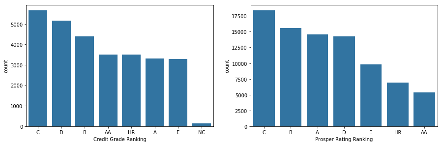

```python
#create a sorted bar chart of relative credit grade and prosper rating frequencies
plt.figure(figsize=[15,10])

base_color = sb.color_palette()[0]

plt.subplot(2,2,1)

credit_counts = loan_df['CreditGrade'].value_counts()
credit_order = credit_counts.index

sb.countplot(data=loan_df, x='CreditGrade', color=base_color, order=credit_order);
plt.xlabel('Credit Grade Ranking');

plt.subplot(2,2,2)

rating_counts = loan_df['ProsperRating (Alpha)'].value_counts()
rating_order = rating_counts.index

sb.countplot(data=loan_df, x='ProsperRating (Alpha)', color=base_color, order=rating_order);
plt.xlabel('Prosper Rating Ranking');
```

C leads as the most rated grade to borrowers both in credit and prosper rating which is generally average.

**LoanStatus** refers to the current status of the loan: Cancelled, Chargedoff, Completed, Current, Defaulted, FinalPaymentInProgress, PastDue. The PastDue status will be accompanied by a delinquency bucket.

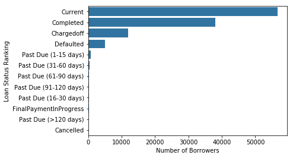

```python
#create a sorted bar chart of relative loan status frequencies
LoanStatus_counts = loan_df['LoanStatus'].value_counts()
LoanStatus_order = LoanStatus_counts.index

base_color = sb.color_palette()[0]
sb.countplot(data=loan_df, y='LoanStatus', color=base_color, order=LoanStatus_order);
plt.ylabel('Loan Status Ranking')
plt.xlabel('Number of Borrowers');
```

Most loans are currently being serviced followed by borrowers who have completed their loan payment. Also,loans are rarely cancelled.

**ListingCreationDate** refers to the date the listing was created.

```python
#Check trend of borrowing period
#First Split the ListCreationDate column to get the year and month
new_loan_df['year'] = new_loan_df['ListingCreationDate'].apply(lambda x: x.split("-")[0]).astype(str)
new_loan_df['month'] = new_loan_df['ListingCreationDate'].apply(lambda x: x.split("-")[1]).astype(str)

new_loan_df.month.unique()
```

```
array(['08', '02', '01', '10', '09', '12', '04', '05', '07', '11', '06',
       '03'], dtype=object)
```

```python
#Replacing the numerical monthly values with their respective names
new_loan_df.replace(['01', '02', '03','04','05','06','07','08','09','10','11','12'], ['Jan', 'Feb','Mar', 'Apr', 'May','June', 'July', 'Aug', 'Sept', 'Oct', 'Nov', 'Dec'], inplace=True)
new_loan_df.month.unique()
```

```
array(['Aug', 'Feb', 'Jan', 'Oct', 'Sept', 'Dec', 'Apr', 'May', 'July',
       'Nov', 'June', 'Mar'], dtype=object)
```

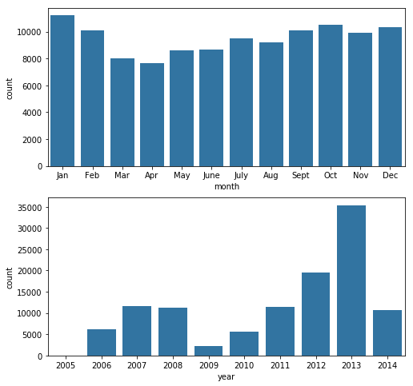

```python
#create a bar chart to show borrowing on a monthly and yearly basis
def month_year_barChart():
    month_order = ['Jan', 'Feb','Mar', 'Apr', 'May','June', 'July', 'Aug', 'Sept', 'Oct', 'Nov', 'Dec']
    year_order = ['2005', '2006', '2007','2008', '2009', '2010', '2011', '2012','2013', '2014']

    ordered_month = pd.api.types.CategoricalDtype(ordered=True, categories=month_order)
    ordered_year = pd.api.types.CategoricalDtype(ordered=True, categories=year_order)

    new_loan_df['month'] = new_loan_df['month'].astype(ordered_month)
    new_loan_df['year'] = new_loan_df['year'].astype(ordered_year)

    fig, ax = plt.subplots(nrows=2, figsize = [8,8])

    default_color = sb.color_palette()[0]
    sb.countplot(data = new_loan_df, x = 'month', color = default_color, ax = ax[0])
    sb.countplot(data = new_loan_df, x = 'year', color = default_color, ax = ax[1])

month_year_barChart();
```

January, October, December, February and September are the top 5 months loans were taken. The year 2013 leading in number of borrowers/loans given out.

**BorrowerState** represents two letter abbreviation of the state of the address of the borrower at the time the Listing was created.

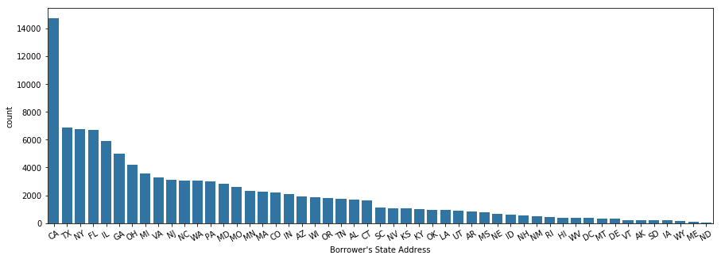

```python
#Create barc chart for borrowers state address
plt.figure(figsize=[15,5])
state_counts = loan_df['BorrowerState'].value_counts()
state_order = state_counts.index

sb.countplot(data=loan_df, x='BorrowerState', color=base_color, order=state_order);
plt.xlabel('Borrower\'s State Address');
plt.xticks(rotation=30);
```

California(CA) residents lead in loan application on the Prosper lending platform. There seems to be a tie in Texas(TX), Newyork(NY) and Florida(FL) which comes in second in using the platform.

North Dakota(ND) state residents are not frequents of this platform.

**LoanOriginalAmount** is the original amount of the loan.

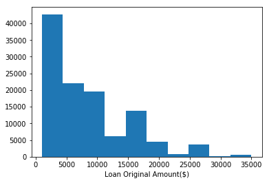

```python
#create distribution of Loan's original amount
def loan_amount():
    plt.hist(data=new_loan_df, x='LoanOriginalAmount');
    plt.xlabel('Loan Original Amount($)')

loan_amount()
```

**DebtToIncomeRatio** refers to the debt to income ratio of the borrower at the time the credit profile was pulled. This value is Null if the debt to income ratio is not available. This value is capped at 10.01 (any debt to income ratio larger than 1000% will be returned as 1001%).

```python
#Fill in missing values of debt to income ratio with the column mean
new_loan_df['DebtToIncomeRatio'] = new_loan_df['DebtToIncomeRatio'].fillna(new_loan_df['DebtToIncomeRatio'].mean())
```

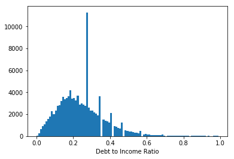

```python
#create distribution of debt to income ratio
bins = np.arange(0, 1, 0.01)
plt.hist(data=new_loan_df, x='DebtToIncomeRatio', bins=bins);
plt.xlabel('Debt to Income Ratio');
```

The debt to income ratio is unimodal with the peak at around 0.3.

**EmploymentStatus** is the employment status of the borrower at the time they posted the listing.

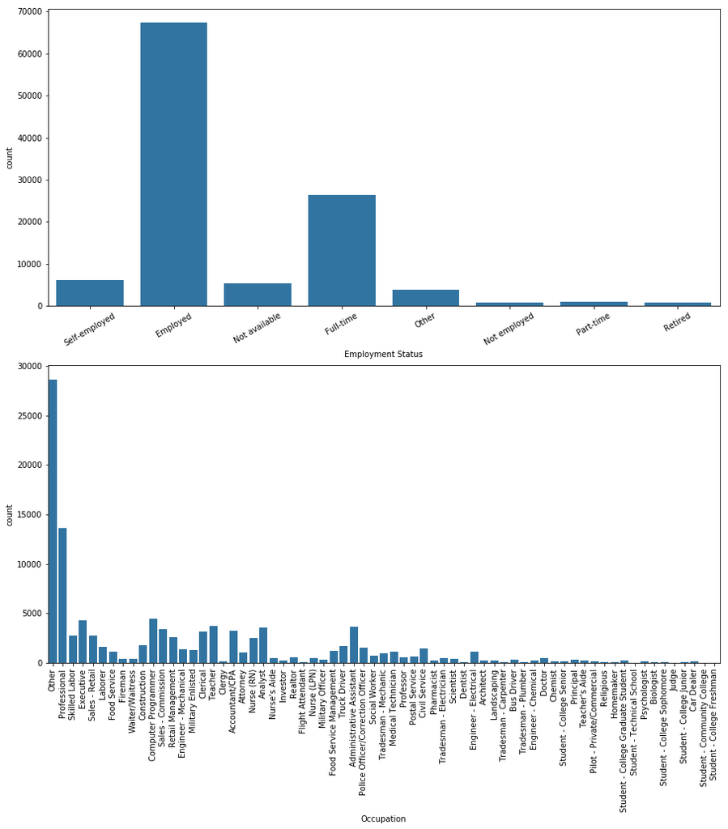

```python
#create distribution for employment status and occupation of the borrower

plt.figure(figsize=[15,15])

default_color = sb.color_palette()[0]

plt.subplot(2,1,1)

sb.countplot(data = new_loan_df, x = 'EmploymentStatus', color = default_color);
plt.xlabel('Employment Status');
plt.xticks(rotation=30);

plt.subplot(2,1,2)

sb.countplot(data = new_loan_df, x = 'Occupation', color = default_color);
plt.xlabel('Occupation');
plt.xticks(rotation=90);
```

Employed people are the most borrowers followed by full time people on this lending platform.

In the occupation status, others which are not specified in the platform are the most borrowers while college freshman students have the least number of borrowers.

### Of the features you investigated, were there any unusual distributions? Did you perform any operations on the data to tidy, adjust, or change the form of the data? If so, why did you do this?

For the debt to income ratio, there are several gaps in the distribution which looks like several distributions in one distribution. I filled the missing values with the column mean to improve the distribution but no major change on the distribution.

## Bivariate Exploration

Firstly, let's look at pairwise correlations present between features in the data.

```python
numeric_vars = ['Term', 'BorrowerAPR', 'BorrowerRate', 'DebtToIncomeRatio', 'StatedMonthlyIncome','MonthlyLoanPayment',
                'LoanOriginalAmount', 'Investors']
categoric_vars = ['CreditGrade', 'LoanStatus', 'ProsperRating (Alpha)', 'EmploymentStatus', 'BorrowerState', 'Occupation']
```

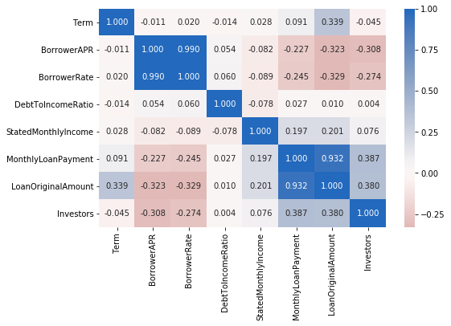

```python
# correlation plot
plt.figure(figsize = [8, 5])
sb.heatmap(new_loan_df[numeric_vars].corr(), annot = True, fmt = '.3f',
           cmap = 'vlag_r', center = 0)
plt.show()
```

Let's look at how loan amount, borrowed APR and monthly payment correlate with the categorical variables

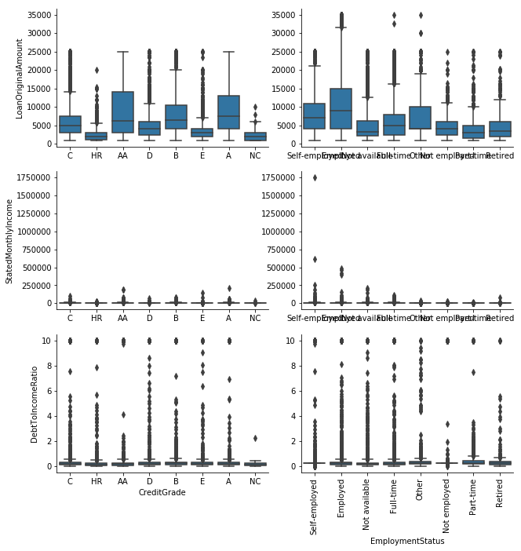

```python
# plot matrix of numeric features against categorical features.


def boxgrid(x, y, **kwargs):

    default_color = sb.color_palette()[0]
    sb.boxplot(x, y, color = default_color)

plt.figure(figsize = [10, 10])
g = sb.PairGrid(data = new_loan_df, y_vars = ['LoanOriginalAmount', 'StatedMonthlyIncome', 'DebtToIncomeRatio'],
                x_vars = ['CreditGrade', 'EmploymentStatus'], size = 3, aspect = 1.5);
g.map(boxgrid);
plt.xticks(rotation=90);
plt.show();
```

There seems to be many outliers for the StatedMonthlyIncome vs CreditGrade and EmploymentStatus respectively which affect the clarity of the distribution. The same applies for the respective DebtToIncomeRatio vs CreditGrade and EmplomentStatus.

Let's create a plots of each of the respective pairs.

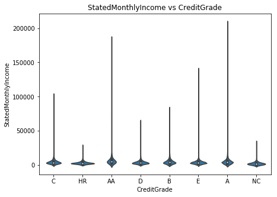

```python
#StatedMonthlyIncome vs CreditGrade
plt.figure(figsize=[7,5])

base_color = sb.color_palette()[0]
sb.violinplot(data=new_loan_df, x='CreditGrade', y='StatedMonthlyIncome', color=base_color);
plt.title('StatedMonthlyIncome vs CreditGrade');
```

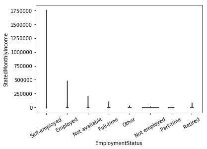

```python
#StatedMonthlyIncome vs EmploymentStatus

base_color = sb.color_palette()[0]

sb.violinplot(data=new_loan_df, x='EmploymentStatus', y='StatedMonthlyIncome', color=base_color, inner=None);
plt.xticks(rotation=30);
```

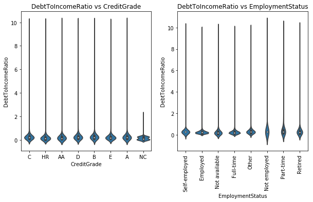

```python
#StatedMonthlyIncome vs CreditGrade
plt.figure(figsize=[10,5])

base_color = sb.color_palette()[0]

plt.subplot(1,2,1) #DebtToIncomeRatio vs CreditGrade

sb.violinplot(data=new_loan_df, x='CreditGrade', y='DebtToIncomeRatio', color=base_color);
plt.title('DebtToIncomeRatio vs CreditGrade');

plt.subplot(1,2,2) #DebtToIncomeRatio vs EmploymentStatus

sb.violinplot(data=new_loan_df, x='EmploymentStatus', y='DebtToIncomeRatio', color=base_color);
plt.title('DebtToIncomeRatio vs EmploymentStatus');
plt.xticks(rotation=90);
```

The above violin plots also show a lot of outliers in the distribution.

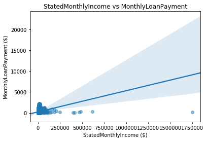

```python
#StatedMonthlyIncome vs MonthlyLoanPayment
sb.regplot(data = new_loan_df, x = 'StatedMonthlyIncome', y = 'MonthlyLoanPayment', x_jitter=0.02,
           scatter_kws={'alpha':0.5});
plt.xlabel('StatedMonthlyIncome ($)')
plt.ylabel('MonthlyLoanPayment ($)')
plt.title('StatedMonthlyIncome vs MonthlyLoanPayment');
```

There is an outlier with $1.75M with the regression line showing a positive correlation which may be difficult to determine using the scatter distribution alone. The positive correlation would make sense for these two variables, that is, the higher your income, the more the payment towards servicing a loan.

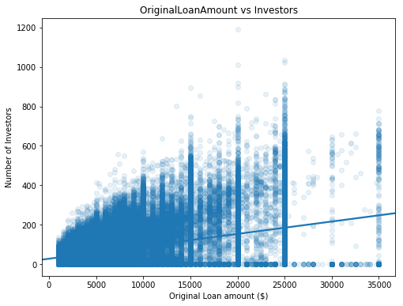

```python
#loan amount vs number of investors

plt.figure(figsize = [8, 6])

sb.regplot(data = new_loan_df, x = 'LoanOriginalAmount', y = 'Investors', scatter_kws={'alpha':0.1})
plt.xlabel('Original Loan amount ($)')
plt.ylabel('Number of Investors')
plt.title('OriginalLoanAmount vs Investors');
```

There seems to be a positive linear relationship between the applicable amount of loan and number of investors. However, there are scenarios where the loan amount is high and the number of investors fewer but funding with a large amount of money for each investor. The vice versa could also be true.

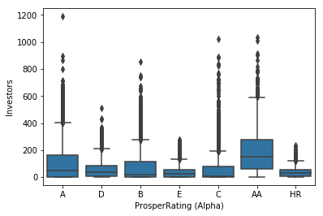

```python
#prosper rating vs number of investors

base_color = sb.color_palette()[0]
sb.boxplot(data=new_loan_df, x = 'ProsperRating (Alpha)', y = 'Investors', color=base_color);
```

Many outliers are observed. From the boxplots, a borrower with a high prosper rating attracts more investors to fund their loan.

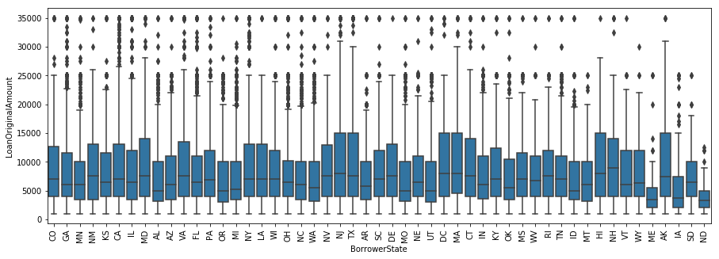

```python
#borrower's state address vs loan amount
plt.figure(figsize = [15,5])
base_color = sb.color_palette()[0]
sb.boxplot(data=new_loan_df, x = 'BorrowerState', y = 'LoanOriginalAmount', color=base_color);
plt.xticks(rotation=90);
```

Earlier, we saw CA residents leading in number applicable loans. From above, I cannot really conclude that the state address a borrower indicates in the loan application will have an effect on the loan amount given.

### Talk about some of the relationships you observed in this part of the investigation. How did the feature(s) of interest vary with other features in the dataset?

Most of the relationships between the numeric variables are weakly correlated either negatively or positively. For example, the relationship between loan amount and the other features show a significantly weak negative or positive correlation except the MonthlyLoanPayment at 0.932. This indicates that the higher the loan amount, the more the monthly loan payment which is logical.

There is a linear relationship between applicable loan amount and number of investors funding the loan. But this can be affected by the theory of a few investors funding with more money or vice versa.

The prosper rating also has an effect on the number of investors considering the rating informs potential investors of possible levels of risk in a loan application.

## Multivariate Exploration

Let's begin with the effect of some features both categorical and numerical on loan amount given and annual rate charged on the loan.

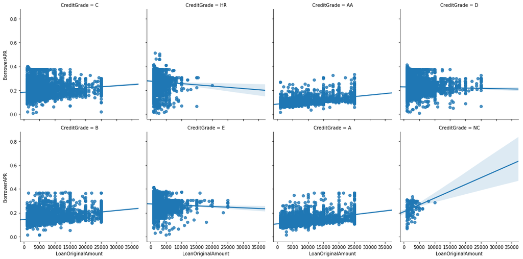

```python
#Effect of CreditGrade on the loan amount and APR to the borrrower

sb.lmplot(data=new_loan_df, x='LoanOriginalAmount', y='BorrowerAPR', col='CreditGrade',
          col_wrap=4, size=4, x_jitter=0.04);
```

For the low ranking credit rating like HR and E, there is an almost downward trajectory in both the loan amount and APR. For the high (A,AA) and average (B,C) credit grades, a slightly upward trajectory is notable.

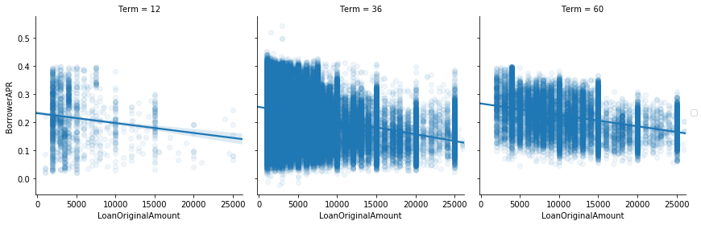

```python
#Effect of Term on the loan amount and APR to the borrrower

g=sb.FacetGrid(data=new_loan_df, col='Term', col_wrap=3, size=4)
g.map(sb.regplot, 'LoanOriginalAmount', 'BorrowerAPR', y_jitter=0.04, scatter_kws = {'alpha' : 1/15}).add_legend();
```

Term does not have an effect on the negative relationship we observed earlier between loan amount and the APR.

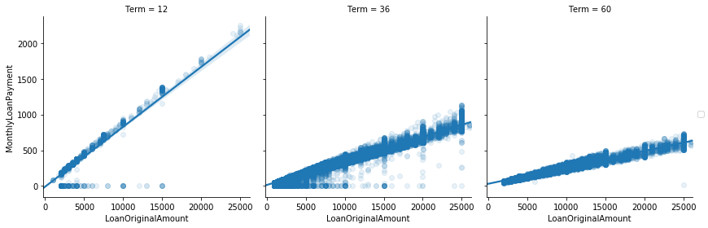

```python
#Effect of Term on the loan amount and Monthly payment

g=sb.FacetGrid(data=new_loan_df, col='Term', col_wrap=3, size=4)
g.map(sb.regplot, 'LoanOriginalAmount', 'MonthlyLoanPayment', x_jitter=0.04, scatter_kws={'alpha':1/10})
g.add_legend();
```

This shows that the original loan amount and the monthly loan payment have a good linear relationship for each term.

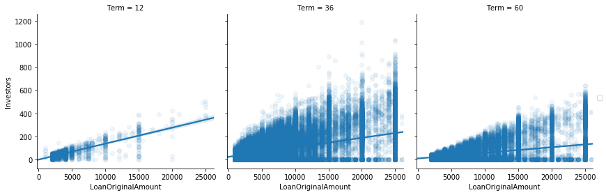

```python
#Effect of Term on the loan amount and Investors

g=sb.FacetGrid(data=new_loan_df, col='Term', col_wrap=3, size=4)
g.map(sb.regplot, 'LoanOriginalAmount', 'Investors', x_jitter=0.04, scatter_kws = {'alpha' : 1/15}).add_legend();
```

There is a linear relationship between loan amount and investors for each term. However, short term attracts more investors to fund the loan as compared to a longer term.

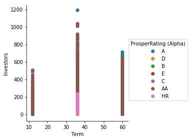

```python
#Effect of Term on the Prosper rating and Investors

g = sb.FacetGrid(data = new_loan_df, hue = 'ProsperRating (Alpha)', size = 4)
g.map(plt.scatter, 'Term', 'Investors').add_legend();
```

For the 12-month term, a higher prosper rating attracts more investors. This also applies for the long 60 months term which only takes high prosper rated borrowers to attract investors.

The 36 months term with HR which is a low rating attracting investors who also their number increases with the increase in the prosper rating.

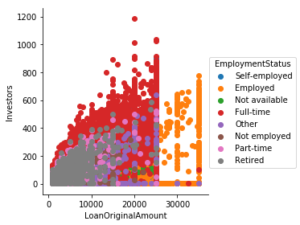

```python
#Effect of Employment status on the loan amount and Investors
g = sb.FacetGrid(data = new_loan_df, hue = 'EmploymentStatus', size = 4)
g.map(plt.scatter, 'LoanOriginalAmount', 'Investors').add_legend();
```

Mostly full time and employed borrowers receive more loan money and subsequently the number of investors funding the loan. This is probably due to consistency that comes with monthly loan payment.

### Talk about some of the relationships you observed in this part of the investigation. Were there features that strengthened each other in terms of looking at your feature(s) of interest?

The credit grade rating has an effect on the given loan amount which subsequently affects the APR charged. The length of the loan is a contributing factor to the borrower's monthly loan payment with short term loan attracting more investors than the long term ones.

### Were there any interesting or surprising interactions between features?

The interaction between the original loan amount and the annual % rate to the borrower whereby the higher the amount of loan given, the lesser the APR incurred.

## Conclusions

- The original loan amount is the most important factor when it comes to deciding on what the monthly loan payment would be. Other factors come into play as well such as Term. As the term increases, the monthly loan payment decreases which is logical.
- Prosper rating is a factor in attracting investors in the loan application with higher prosper rating attracting more investors to fund the loan. Moreover, short term (12 months) and long term (60 months) loans require a high prosper rating in order to attract more investors.
- Status of employment is a factor in the amount of loan a borrower is given which subsequently affects the number of investors funding the applicable loans.

### Limitation

- The dataset was intense with many variables. I created a subset to work with the necessary features for data exploration.

### References

- https://classroom.udacity.com
- https://stackoverflow.com/
- https://www.prosper.com
- https://seaborn.pydata.org/generated/seaborn.FacetGrid.html
- https://rstudio-pubs-static.s3.amazonaws.com/284488_195ef48d299e46f5b009987c8b988b69.html
- https://moonbooks.org/Articles/How-to-create-a-table-of-contents-in-a-jupyter-notebook-/